# Visualizing Data for Pattern Discovery

> Exploring different ways to visualize high dimensional data to find its inherent structure for pattern discovery

Dataset Used for the demonstration:

Customer purchase data, where each record is a customer's spending amount on around 200 different products(200 columns)

Outcome variable is a binary variable with WON or LOST. WON if the customer bought the product of interest,Product X(not included in the 200 columns) and LOST otherwise >

The actual goal was to do a cross sell analysis but this document is mainly to demonstrate differnet ways to visualize data

*Description for each plot privided below them

## Plots

### 3-D view of the data - T-sne

[interactive chart not shown]

> Zoom and rotate options available
- 3D plot of all the customers
- Algorithm used: t-distributed stochastic neighbor embedding(t-sne), two dimentional plot also is available
- R Packages: "tsne", "Rtsne", "plot3D"
- Each data point represents a customers purchase behaviour, i.e., a 3 dimensional approximation of the 200 dimensions
- Red dots are the wins
- You can see there are two flares on the side that have higher concentrations of wins, from which we may infer there are certain purchase behaviors that result in more wins

### 2-Dimensional Grid View(Self organizing Map)

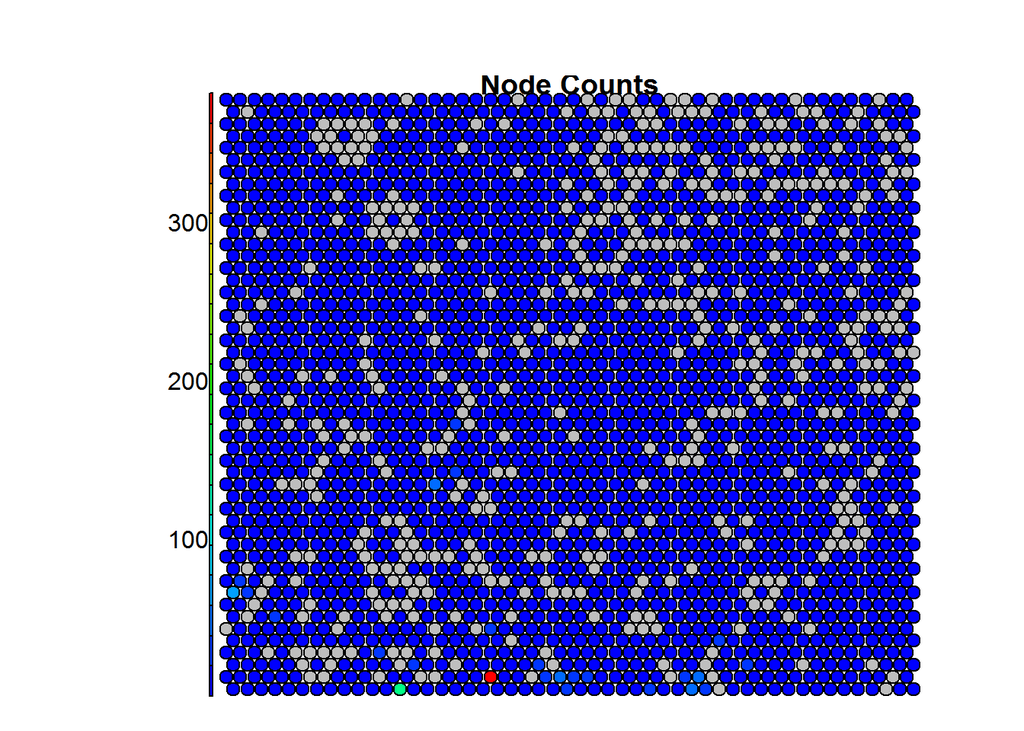

> Description Below

> 2-Dimensional Grid View of customers based on their spending patterns/purchase behaviour
- Algorithm used: Self Organizing Map(Kohonen's Neural Network), which is a non linear dimensionality reduction technique(unlike PCA which is linear)
- R package: "kohonen
- This is based on the distance between points(200 dimensional data points)
- This is a grid view, where each node represents a group of customers(one or more) and not just a single customer
- Each Node represents a group of customers having similar spending patterns/purchase behaviour.
- some nodes have more customers , like the red dot which has around 400 customers.
- Nodes farther from each other represent customer groups having dissimilar purchase behaviour

**Pros:** Easy pattern discovery using heatmaps (Further heatmap analysis in separate section below)

**Cons:** Not very intuitive visually as node size remains the same irrespective of the number of customers in a node

### Network graph - D3(TDA Mapper)

[interactive chart not shown]

> Network View of customers based on their purchase behaviour(zoom out for better biew)
- Algorithm used: TDA Mapper (Topological data analysis)
- R Packages: "TDAmapper, "networkD3"
- D3 interface with R
- Size of each node based on the number of customers in a Node and distance based on the similarity
- Similar Nodes are connencted with Edges

**Pros:** Lot of scope for Business specific customization and good for long term projects to develop  
customized visualization applications

**cons:** Algorithm is computationally expensive

## More about the 2-D Grid View of the data/ Self Organizing Map

### Where are the “WON” customers??

Below is the purchase behavior heatmap with Nodes having higher WON customers.The closer to Red the higher the concentration of wins in that node

**We can see that most of them are scattered but a good portion of the wins seem to be clustered around a specific area**

We then have to explore what other prducts do customers in that area of the purchase behavior map spend on

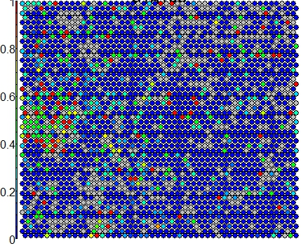

Wins for Product X

## What other customers are there in that area of the purchase behavior map?

After querying for the top products in those nodes, few products in particular were found to have higher demand in that area. Let's call them products A,B,C and D. Below are their respecctive heatmaps

### Product A

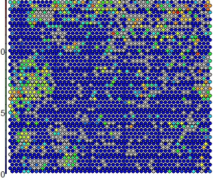

### Product B

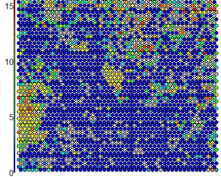

### Product C

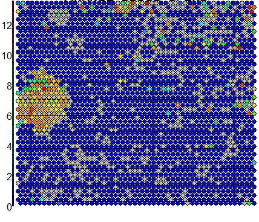

### Product D

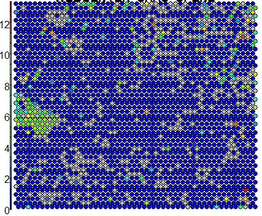

## Coclusion

Though all three methods are for making a low dimensional representation of a high dimensional space, they have different approaches

**You have to tune and try differnet parameters till you find a consistent representation, otherwise you might end up with a misleading result**

Though I spent more time on the self organizing map, TDA(Topological data analysis) is very powerful and can reveal hidden patterns

Here is a video explaining the [TDA Mapper Algorithm](https://www.youtube.com/watch?v=F2t_ytTLrQ4&t=3s)